# Python Notebook for S-map for DE and ODE models

### [0] Setting Python environment (in RStudio)

Download Python environment: https://www.python.org/downloads/

#### [0.1] Loading the package for Python environment

```r
library(reticulate)
```

#### [0.2] Installing libraries & Loading classes

In R chunk

```r
library_name = "pandas"
if (py_module_available(library_name)) {
  message(paste("The library", library_name, "is already installed."))
} else {
  message(paste("The library", library_name, "is not installed. Installing now..."))
  py_install(library_name)
}
```

[output not shown]

```r
library_name = "matplotlib"
if (py_module_available(library_name)) {
  message(paste("The library", library_name, "is already installed."))
} else {
  message(paste("The library", library_name, "is not installed. Installing now..."))
  py_install(library_name)
}
```

```
The library matplotlib is already installed.
```

```r
library_name = "pyEDM"
if (py_module_available(library_name)) {
  message(paste("The library", library_name, "is already installed."))
} else {
  message(paste("The library", library_name, "is not installed. Installing now..."))
  py_install(library_name)
}
```

```
The library pyEDM is already installed.
```

In Python chunk

```python
reticulate::repl_python()
import numpy as np   #for numerical calculations
import pandas as pd
import math    #for mathematical functions
import pyEDM   #for EDM analysis
import matplotlib.pyplot as plt   #for graphics
import multiprocessing as mp #for paralell computing
from numpy import exp
```

### [1] General functions for ODEs

4th-order explicit Runge-Kutta method with a fixed interval function

```python
def rk4(in_vec, out_vec, time, h_interval, dim, diff_vec, ref_data = None):
    #in_vec: the vector with the value at "time"
    #out_vec: the vector with which the updated vector value after one time step is saved
    #time: time value
    #h_interval: time step for discritizing ODE
    #dim: dimension of the ODE
    #diff_vec: function that determines the r.h.s. of the ODE

    k1 = np.zeros([dim])
    k2 = np.zeros([dim])
    k3 = np.zeros([dim])
    k4 = np.zeros([dim])

    temp_vec = np.zeros([dim])
    h_half = h_interval / 2.0
    t_h = time + h_half

    k1 = diff_vec(in_vec, time, h_interval, dim, ref_data)  # calculate k1
    temp_vec = in_vec + h_half * k1
    k2 = diff_vec(temp_vec, t_h, h_interval, dim, ref_data)  # calculate k2
    temp_vec = in_vec + h_half * k2
    k3 = diff_vec(temp_vec, t_h, h_interval, dim, ref_data)  # calculate k3
    temp_vec = in_vec + h_interval * k3
    k4 = diff_vec(temp_vec, time + h_interval, h_interval, dim, ref_data)  # calculate k4

    for i in range(0, dim):
      out_vec[i] = in_vec[i] + (h_interval / 6.0) * (k1[i] + 2.0 * k2[i] + 2.0 * k3[i] + k4[i])
```

### [2] Model01 setting

Interaction strength estimation for time-discrete model (DE) framework

#### [2.1] Model equations

2-Host 2-Parasitoid System with natural mortality (i.e., with overlapping generations)

Note: When the natural mortality goes to infinity, the model converges to 2-Host 2-Parasitoid Nicolson-Baily Model

$$H_{k,t+1} = H_{k,t} + r_k exp[-a_{k}H_{k,t} - c_{1k} P_{1,t} - c_{2k}
P_{2, t}] H_{k,t} - (1 - exp[-a_{k}H_{k,t} - c_{1k} P_{1,t} - c_{2k}
P_{2,t} - m_{H,k}]) H_{k,t} \quad (k=1,2) \tag{D1}$$
It is set as
$$H_{k,t+1} = H_{k,t} + F_{Hk}(H_{1,t}, H_{2,t}, P_{1,t}, P_{2,t})$$

$$P_{j,t+1} = P_{j,t} + \sum_{k=1,2} exp(-a_k H_{k,t}) (1 - exp[-c_{1k}
P_{1,t} - c_{2k} P_{2,t}]) \frac{c_{jk} P_{j,t}}{c_{1k} P_{1,t} + c_{2k}
P_{2,t}} H_{k,t} -(1 - exp(-m_{P,j})) P_{j,t} \quad (j=1,2) \tag{D2}$$
It is set as
$$P_{j,t+1} = P_{j,t} + F_{Pj}(H_{1,t}, H_{2,t}, P_{1,t}, P_{2,t})$$

#### [2.2] Parameters and settings for the 4-species coupled host-parasitoid model

##### [2.2.1] Parameter value setting

```python
r1 = 2.0
r2 = 2.0
a1 = 0.1
a2 = 0.1
c11 = 0.3 #P1 -> H1
c21 = 0.1 #P2 -> H1
c12 = 0.1 #P1 -> H2
c22 = 0.3 #P2 -> H2
mH1 = 0.1
mH2 = 0.1
mP1 = 0.1
mP2 = 0.1
```

##### [2.2.2] Setting for numerical calculations

```python
j_Host1 = 0
j_Host2 = 1
j_Paras1 = 2
j_Paras2 = 3
```

##### [2.2.3] Functions specific to 4-sp model

Note that FH1, FH2, FP1, FP2, are defined as the changes of the abundance (X_t+1 - X_t)

```python
def FH1(in_vec, t):
  term1 = r1*exp(-a1 * in_vec[j_Host1] - c11 * in_vec[j_Paras1] - c21 * in_vec[j_Paras2]) * in_vec[j_Host1]
  term2 = (1.0 - exp(-a1 * in_vec[j_Host1] - c11 * in_vec[j_Paras1] - c21 * in_vec[j_Paras2] - mH1)) * in_vec[j_Host1]
  return term1 - term2

def FH2(in_vec, t):
  term1 = r2*exp(-a2 * in_vec[j_Host2] - c12 * in_vec[j_Paras1] - c22 * in_vec[j_Paras2]) * in_vec[j_Host2]
  term2 = (1.0 - exp(-a2 * in_vec[j_Host2] - c12 * in_vec[j_Paras1] - c22 * in_vec[j_Paras2] - mH2)) * in_vec[j_Host2]
  return term1 - term2

def FP1(in_vec, t):
  term1 = exp(-a1 * in_vec[j_Host1]) * (1 - exp(-c11 * in_vec[j_Paras1] - c21 * in_vec[j_Paras2])) * c11 * in_vec[j_Paras1] / (c11 * in_vec[j_Paras1] + c21 * in_vec[j_Paras2]) * in_vec[j_Host1]

  term2 = exp(-a2 * in_vec[j_Host2]) * (1 - exp(-c12 * in_vec[j_Paras1] - c22 * in_vec[j_Paras2])) * c12 * in_vec[j_Paras1] / (c12 * in_vec[j_Paras1] + c22 * in_vec[j_Paras2]) * in_vec[j_Host2]

  term3 = (1.0 - exp(-mP1)) * in_vec[j_Paras1]
  return term1 + term2 - term3


def FP2(in_vec, t):
  term1 = exp(-a1 * in_vec[j_Host1]) * (1 - exp(-c11 * in_vec[j_Paras1] - c21 * in_vec[j_Paras2])) * c21 * in_vec[j_Paras2] / (c11 * in_vec[j_Paras1] + c21 * in_vec[j_Paras2]) * in_vec[j_Host1]

  term2 = exp(-a2 * in_vec[j_Host2]) * (1 - exp(-c12 * in_vec[j_Paras1] - c22 * in_vec[j_Paras2])) * c22 * in_vec[j_Paras2] / (c12 * in_vec[j_Paras1] + c22 * in_vec[j_Paras2]) * in_vec[j_Host2]

  term3 = (1.0 - exp(-mP2)) * in_vec[j_Paras2]
  return term1 + term2 - term3

#function to calculate all changes four dimensional
def diff_4HP(in_vec, t, dim):
  temp_vec = np.zeros([dim])
  temp_vec[j_Host1] = FH1(in_vec, t)
  temp_vec[j_Host2] = FH2(in_vec, t)
  temp_vec[j_Paras1] = FP1(in_vec, t)
  temp_vec[j_Paras2] = FP2(in_vec, t)
  return temp_vec
```

##### [2.2.4] Initial setting and conditions

```python
dim_model2 = 4
nv_4HP0 = np.zeros([dim_model2])
nv_4HP = np.zeros([dim_model2])

nv_4HP0[j_Host1] = 1.0
nv_4HP0[j_Host2] = 1.0
nv_4HP0[j_Paras1] = 0.1
nv_4HP0[j_Paras2] = 0.1
```

#### [2.3] Solving the model

##### [2.3.2] Trial with two pairs of Host - Parasitoid system

Running the model

```python
t = 0  # initial condition (initial time, 0)
end_time = 2000

HP_result = np.zeros([end_time + 1, dim_model2 + 1]) #array for saving the time series generated

#Setting initial condition; it is important to start with asymmetric densities to reach quickly the chaotic attractor
nv_4HP[j_Host1] = 1.0
nv_4HP[j_Host2] = 0.5
nv_4HP[j_Paras1] = 0.1
nv_4HP[j_Paras2] = 0.2

#record initial condition
HP_result[0, 1:] = nv_4HP

#For the transient dynamics
for i in range (1, (end_time + 1)):
  nv_4HP = nv_4HP + diff_4HP(nv_4HP, t, dim_model2)
  t = t + 1 #update time
  HP_result[i, 0] = t
  HP_result[i, 1:] = nv_4HP

print(HP_result)
```

```
[[0.00000000e+00 1.00000000e+00 5.00000000e-01 1.00000000e-01
  2.00000000e-01]
 [1.00000000e+00 2.50021674e+00 1.28817984e+00 1.21554906e-01
  2.26180255e-01]
 [2.00000000e+00 5.33158557e+00 3.03672646e+00 1.92164980e-01
  3.21270591e-01]
 ...
 [1.99800000e+03 6.36366589e-01 6.11649709e-01 2.96019842e+00
  3.58294269e+00]
 [1.99900000e+03 4.98778328e-01 4.24312219e-01 3.07432180e+00
  3.70087140e+00]
 [2.00000000e+03 3.78523317e-01 2.86208954e-01 3.09422302e+00
  3.68858433e+00]]
```

Plotting the time series

```python
plt.clf() #clear the figure setting
plt.xlim([0, end_time])
plt.ylim([0, 5])
```

```
(0.0, 5.0)
```

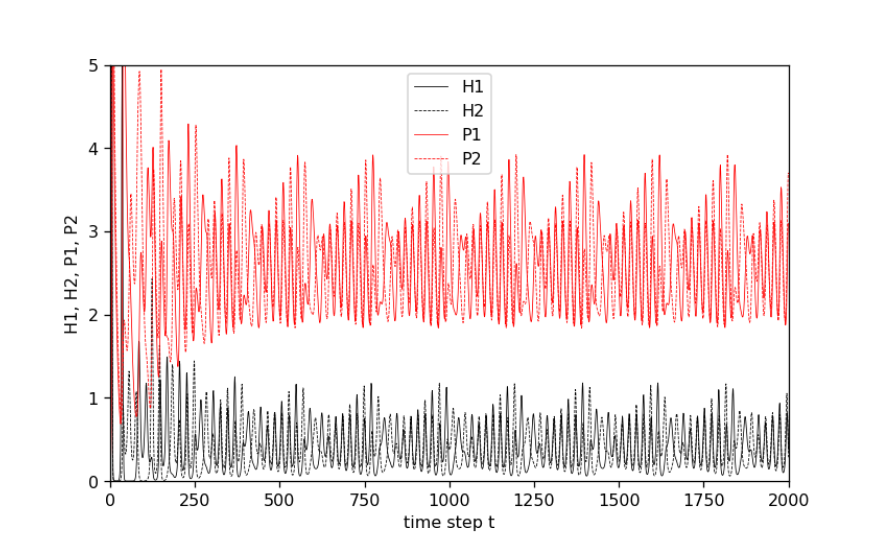

```python
plt.plot(HP_result[:, 0], HP_result[:, j_Host1 + 1], color = "black", label = "H1", linestyle = "solid", linewidth = 0.5)
plt.plot(HP_result[:, 0], HP_result[:, j_Paras1 + 1], color = "red", label = "P1", linestyle = "solid", linewidth = 0.5)
plt.xlabel('time step t')
plt.legend()
plt.show()
```

Converting the array to dataframe for pyEDM

```python
HP_result_df = pd.DataFrame(HP_result, columns = ["time", "H1", "H2", "P1", "P2"])
print(HP_result_df)
```

```
        time        H1        H2        P1        P2
0        0.0  1.000000  0.500000  0.100000  0.200000
1        1.0  2.500217  1.288180  0.121555  0.226180
2        2.0  5.331586  3.036726  0.192165  0.321271
3        3.0  8.306937  5.800170  0.387040  0.590833
4        4.0  8.824918  7.601106  0.848789  1.248487
...      ...       ...       ...       ...       ...
1996  1996.0  0.810851  0.986555  2.519284  3.004652
1997  1997.0  0.755309  0.819436  2.762130  3.335593
1998  1998.0  0.636367  0.611650  2.960198  3.582943
1999  1999.0  0.498778  0.424312  3.074322  3.700871
2000  2000.0  0.378523  0.286209  3.094223  3.688584

[2001 rows x 5 columns]
```

### [3] A simple analysis with multivariate S-map

Based on https://ushio-ecology-blog.blogspot.com/2019/12/20191225blogger0007.html

#### [3.1] Analysis with standardization

Subset of the final part of the generated time series

```python
HP_result_df = HP_result_df.loc[1800:1999]
print(HP_result_df)
```

```
        time        H1        H2        P1        P2
1800  1800.0  0.225324  0.338716  3.722649  3.011423
1801  1801.0  0.155003  0.265596  3.568749  2.927438
1802  1802.0  0.113404  0.218479  3.371328  2.803667
1803  1803.0  0.089499  0.191136  3.156505  2.660134
1804  1804.0  0.076607  0.178852  2.940481  2.510908
...      ...       ...       ...       ...       ...
1995  1995.0  0.780946  1.053216  2.282091  2.660773
1996  1996.0  0.810851  0.986555  2.519284  3.004652
1997  1997.0  0.755309  0.819436  2.762130  3.335593
1998  1998.0  0.636367  0.611650  2.960198  3.582943
1999  1999.0  0.498778  0.424312  3.074322  3.700871

[200 rows x 5 columns]
```

##### [3.1.1] Standardization

```python
HP_result_mean = HP_result_df.iloc[:, 1:].mean(axis = 0, skipna = True)  # mean abundance
HP_result_sd = HP_result_df.iloc[:, 1:].std(axis = 0, skipna = True)      # SD of abundance
print(HP_result_mean)
print(HP_result_sd)
```

```
H1    0.241957
H2    0.250917
P1    0.476845
P2    0.481405
dtype: float64
```

```python
HP_result_s = (HP_result_df.iloc[:, 1:] - HP_result_mean) / HP_result_sd # Standardized data set
#add the first column as time
HP_result_s.insert(0, "time", HP_result_df.iloc[:, 0])
print(HP_result_s)
```

```
        time        H1        H2        P1        P2
1800  1800.0 -0.707507 -0.300696  2.441895  0.924019
1801  1801.0 -0.998140 -0.592107  2.119148  0.749560
1802  1802.0 -1.170069 -0.779888  1.705133  0.492458
1803  1803.0 -1.268867 -0.888859  1.254625  0.194303
1804  1804.0 -1.322149 -0.937816  0.801596 -0.115676
...      ...       ...       ...       ...       ...
1995  1995.0  1.588864  2.546854 -0.579126  0.195630
1996  1996.0  1.712460  2.281183 -0.081704  0.909953
1997  1997.0  1.482905  1.615154  0.427573  1.597400
1998  1998.0  0.991321  0.787046  0.842946  2.111208
1999  1999.0  0.422673  0.040436  1.082276  2.356176

[200 rows x 5 columns]
```

##### [3.1.2] Analysis with the standardized time series data

- Conducting univariate smap for obtaining the optimal theta
- But do not use the result, because R version determined the optimal theta by the minimum rmse while pyEDM’s function returns the correlation coefficient rho only.

```
    theta       rho
0    0.01  0.999825
1    0.10  0.999838
2    0.30  0.999863
3    0.50  0.999883
4    0.75  0.999901
5    1.00  0.999915
6    1.50  0.999934
7    2.00  0.999947
8    3.00  0.999963
9    4.00  0.999969
10   5.00  0.999970
11   6.00  0.999969
12   7.00  0.999968
13   8.00  0.999967
14   9.00  0.999966
```

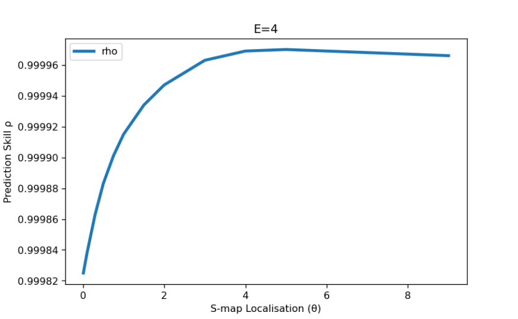

```python
result_optimal_theta_H1 = pyEDM.PredictNonlinear(dataFrame = HP_result_s, columns = "H1", target = "H1",  lib = [1, 200], pred = [1, 200], E = 4)
print(result_optimal_theta_H1)
```

Conducting multivariate Smap with the optimal theta (= 8, based on the result from rEDM)

- Note that time index for the coefficient is different from the outcome of rEDM

```python
multivariate_Smap_HP = pyEDM.SMap(dataFrame = HP_result_s, columns = ["H1", "H2", "P1", "P2"], target = "H1", lib = [1, 200], pred = [1, 200], theta = 8, verbose = False, showPlot = False, embedded = True)
type(multivariate_Smap_HP['coefficients'])
print(multivariate_Smap_HP['coefficients'])
```

```
<class 'pandas.core.frame.DataFrame'>
       Time        C0   ∂H1/∂H1   ∂H1/∂H2   ∂H1/∂P1   ∂H1/∂P2
0    1800.0       NaN       NaN       NaN       NaN       NaN
1    1801.0 -0.215430  0.730878 -0.015146 -0.100887 -0.032644
2    1802.0 -0.207323  0.780447 -0.023968 -0.090281 -0.029011
3    1803.0 -0.191153  0.834904 -0.029206 -0.070513 -0.026971
4    1804.0 -0.132931  0.895315 -0.023354 -0.058796 -0.028531
..      ...       ...       ...       ...       ...       ...
196  1996.0 -0.013573  0.956888 -0.019060 -0.452752 -0.139203
197  1997.0  0.059116  0.892899  0.003680 -0.411512 -0.145519
198  1998.0  0.156866  0.808116  0.005272 -0.355757 -0.129178
199  1999.0  0.154924  0.763186  0.004816 -0.304236 -0.110654
200  2000.0  0.011598  0.774902 -0.006914 -0.217162 -0.073424

[201 rows x 6 columns]
```

##### [3.1.3] Plotting the results

We can see that the adjustment of the diagonal elements makes the intraspecific interaction strengths comparable to the iterspecific interaction strengths.

```python
Smap_HP_coeffcients = multivariate_Smap_HP['coefficients']
delta_11 = 1 #adjustment for the diagonal elements

plt.clf() #clear the figure setting
plt.xlim([1800, 2000])
```

```
(1800.0, 2000.0)
(-0.6, 1.6)
```

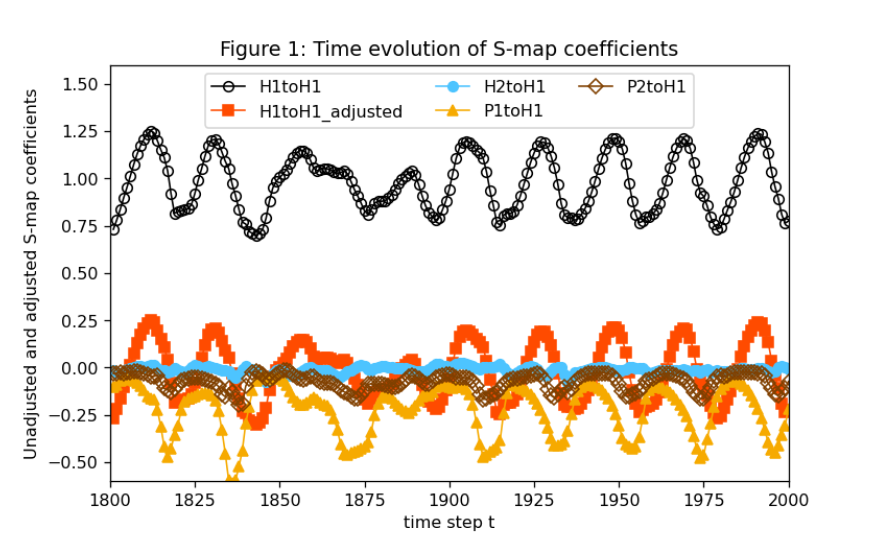

```python
plt.plot(Smap_HP_coeffcients["Time"][1:], Smap_HP_coeffcients["∂H1/∂H1"][1:], color = "black", label = "H1toH1", linestyle = "solid", linewidth = 1.0, marker = "o", fillstyle = 'none')
plt.plot(Smap_HP_coeffcients["Time"][1:], Smap_HP_coeffcients["∂H1/∂H1"][1:] - delta_11, color = "#ff4b00", label = "H1toH1_adjusted", linestyle = "solid", linewidth = 1.0, marker = "s")
plt.plot(Smap_HP_coeffcients["Time"][1:], Smap_HP_coeffcients["∂H1/∂H2"][1:], color = "#4dc4ff", label = "H2toH1", linestyle = "solid", linewidth = 1.0, marker = "o")
plt.plot(Smap_HP_coeffcients["Time"][1:], Smap_HP_coeffcients["∂H1/∂P1"][1:], color = "#f6aa00", label = "P1toH1", linestyle = "solid", linewidth = 1.0, marker = "^")
plt.plot(Smap_HP_coeffcients["Time"][1:], Smap_HP_coeffcients["∂H1/∂P2"][1:], color = "#804000", label = "P2toH1", linestyle = "solid", linewidth = 1.0, marker = "D", fillstyle = 'none')
plt.xlabel('time step t')
plt.ylabel('Unadjusted and adjusted S-map coefficients')
plt.show()
```

### [5] Model02 setting

#### [5.1] Model equations for the 5-species coupled food chain ODE model

$$\frac{dP_i}{dt} = v_i \lambda_i \frac{P_i C_i}{C_i + C_i^*} - v_i P_i,
\quad (i=1,2) \tag{1}$$

$$\frac{dC_i}{dt} = \mu_i \kappa_i \frac{C_i R}{R + R^*} - v_i \lambda_i
\frac{P_i C_i}{C_i + C_i^*} - \mu_i C_i, \quad (i=1,2) \tag{2}$$

$$\frac{dR}{dt} = R \left( 1 - \frac{R}{k} \right) - \sum_{i=1,2} \mu_i
\kappa_i \frac{C_iR}{R + R^*}.\tag{3}$$

#### [5.2] Parameters and settings for the 5-species coupled food chain ODE model

##### [5.2.1] Parameter value setting

```python
v1 = 0.1
v2 = 0.07
lambd1 = 3.2
lambd2 = 2.9
Cstar1 = 0.5
Cstar2 = 0.5
myu1 = 0.15
myu2 = 0.15
kp1 = 2.5
kp2 = 2.0
Rstar = 0.3
k = 1.2
```

##### [5.2.2] Settings for numerically solving ODEs

```python
j_P1 = 0
j_P2 = 1
j_C1 = 2
j_C2 = 3
j_R = 4
```

##### [5.2.3] Functions specific to the 5-sp model

```python
def dP1dt(in_vec, t):
  growth = v1 * lambd1 * in_vec[j_P1] * in_vec[j_C1] / (in_vec[j_C1] + Cstar1)
  mortality =  v1 * in_vec[j_P1]
  return growth - mortality

def dP2dt(in_vec, t):
  growth = v2 * lambd2 * in_vec[j_P2] * in_vec[j_C2] / (in_vec[j_C2] + Cstar2)
  mortality = v2 * in_vec[j_P2]
  return growth - mortality

def dC1dt(in_vec, t):
  growth = myu1 * kp1 * in_vec[j_C1] * in_vec[j_R] / (in_vec[j_R] + Rstar)
  mortality = v1 * lambd1 * in_vec[j_P1] * in_vec[j_C1] / (in_vec[j_C1] + Cstar1) + myu1 * in_vec[j_C1]
  return growth - mortality

def dC2dt(in_vec, t):
  growth = myu2 * kp2 * in_vec[j_C2] * in_vec[j_R] / (in_vec[j_R] + Rstar)
  mortality  = v2 * lambd2 * in_vec[j_P2] * in_vec[j_C2] / (in_vec[j_C2] + Cstar2) + myu2 * in_vec[j_C2]
  return growth - mortality

def dRdt(in_vec, t):
  growth = in_vec[j_R] * (1.0 - in_vec[j_R] / k)
  mortality = myu1 * kp1 * in_vec[j_C1] * in_vec[j_R] / (in_vec[j_R] + Rstar) + myu2 * kp2 * in_vec[j_C2] * in_vec[j_R] / (in_vec[j_R] + Rstar)
  return growth - mortality

#function to calculate all coefficients, five dimensional
def diff_5sp(in_vec, t, h_interval, dim, ref_data = None):
  temp_vec = np.zeros([dim])
  temp_vec[j_P1] = dP1dt(in_vec, t)
  temp_vec[j_P2] = dP2dt(in_vec, t)
  temp_vec[j_C1] = dC1dt(in_vec, t)
  temp_vec[j_C2] = dC2dt(in_vec, t)
  temp_vec[j_R] = dRdt(in_vec, t)
  return temp_vec
```

##### [5.2.4] Initial setting and conditions

```python
dim_model1 = 5
nv = np.zeros([dim_model1])
deltat = 0.01
```

#### [5.3] Solving the model

##### [5.3.1] Solving the model by the RK4 method

```python
t = 0.0  # initial condition (initial time, 0)
end_time = 2000
tau = 5
transient_period = 1000
write_index = 1

no_step = int((end_time - transient_period) / tau) + 1
rk4_result = np.zeros([no_step, dim_model1 + 1]) #array for saving the time series generated

#Initial condition set
nv[j_R] = 1.0
nv[j_C1] = 0.5
nv[j_C2] = 0.8
nv[j_P1] = 0.7
nv[j_P2] = 0.8
print(nv)
```

```
[0.7 0.8 0.5 0.8 1. ]
```

```python
#For the transient dynamics (RUN BURN)
for i in range(1, int(transient_period / deltat) + 1):
  rk4(in_vec = nv, out_vec = nv, time = t, h_interval = deltat, dim = dim_model1, diff_vec = diff_5sp)
  t = t + deltat # update time

#record the initial condition after BURNING phase
rk4_result[0, 0] = t
rk4_result[0, 1:] = nv

#After transient period
j = 0
for i in range(1, int((end_time - transient_period) / deltat) + 1):
  rk4(in_vec = nv, out_vec = nv, time = t, h_interval = deltat, dim = dim_model1, diff_vec = diff_5sp)
  t = t + deltat # update time
  ###record the result every "tau only
  if write_index < int(tau / deltat):
    write_index += 1
  else:
    write_index =  1
    j += 1
    rk4_result[j, 0] = t
    rk4_result[j, 1:] = nv
print(rk4_result)
```

```
[[1.00000000e+03 2.85950151e-02 6.63480153e-04 5.83208146e-01
  8.39888620e-05 1.02549882e+00]
 [1.00500000e+03 4.64428277e-02 4.67644363e-04 1.09522243e+00
  1.23795726e-04 8.45711900e-01]
 [1.01000000e+03 9.19413112e-02 3.29640462e-04 1.77063991e+00
  1.63230066e-04 4.35519176e-01]
 ...
 [1.99000000e+03 1.29630930e-01 3.12079221e-02 3.46010623e-01
  4.51556765e-03 1.83207221e-02]
 [1.99500000e+03 1.33176519e-01 2.21463809e-02 2.05256023e-01
  3.05227415e-03 4.63373565e-01]
 [2.00000000e+03 1.35590879e-01 1.57180456e-02 2.92786347e-01
  4.23056820e-03 1.09448525e+00]]
```

```python
rk4_result_df = pd.DataFrame(rk4_result, columns = ["time", "P1", "P2", "C1", "C2", "R"])
print(rk4_result_df)
```

```
       time        P1        P2        C1        C2         R
0    1000.0  0.028595  0.000663  0.583208  0.000084  1.025499
1    1005.0  0.046443  0.000468  1.095222  0.000124  0.845712
2    1010.0  0.091941  0.000330  1.770640  0.000163  0.435519
3    1015.0  0.192952  0.000232  1.389954  0.000125  0.022597
4    1020.0  0.322498  0.000164  0.515130  0.000063  0.013542
..      ...       ...       ...       ...       ...       ...
196  1980.0  0.049296  0.060157  1.743435  0.021799  0.056084
197  1985.0  0.093124  0.043685  0.835769  0.009932  0.004007
198  1990.0  0.129631  0.031208  0.346011  0.004516  0.018321
199  1995.0  0.133177  0.022146  0.205256  0.003052  0.463374
200  2000.0  0.135591  0.015718  0.292786  0.004231  1.094485

[201 rows x 6 columns]
```

##### [5.3.2] Basic plot for the result

```python
plt.clf() #clear the figure setting
plt.xlim([transient_period, end_time])
```

```
(1000.0, 2000.0)
(0.0, 2.0)
```

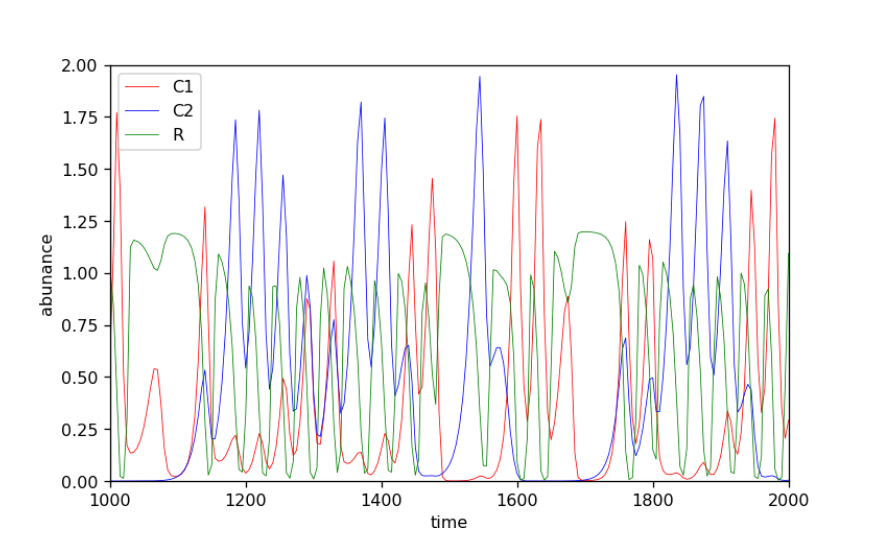

```python
plt.plot(rk4_result_df["time"], rk4_result_df["C2"], color = "blue", label = "C2", linestyle = "solid", linewidth = 0.5)
plt.plot(rk4_result_df["time"], rk4_result_df["R"], color = "green", label = "R", linestyle = "solid", linewidth = 0.5)
plt.xlabel('time')
plt.legend()
plt.show()
```

### [6] Theoretical coefficients evaluated by instantaneous Jacobian

The partial derivative of dC1/dt

with respect to C1:
$$\frac{\partial}{\partial C_{1}} \left( \mu_{1} K_{1} \frac{C_{1} R}{R +
R^{*}} - v_{1} \lambda_{1} \frac{P_{1} C_{1}}{C_{1} + C_{1}^{*}} -
\mu_{1} C_{1} \right) = K_{1} \mu_{1} \frac{R}{R + R^{*}} - v_{1}
\lambda_{1} \frac{P_{1} C_{1}*}{(C_{1} + C_{1}^{*})^2} - \mu_{1}$$

with respect to R:
$$\frac{\partial}{\partial R} \left( \mu_{1} \kappa_{1} \frac{C_{1} R}{R +
R^{*}} \right) = \kappa_{1} \mu_{1} \frac{C_{1} R^*}{(R + R^{*})^2}$$

Function definition

```python
def dC1dC1(data):
  coeff = myu1 * kp1 * data["R"] / (data["R"] + Rstar) - v1 * lambd1 * data["P1"] * Cstar1/ (data["C1"] + Cstar1) ** 2 - myu1
  return coeff

def dC1dR(data):
  coeff = myu1 * kp1 * data["C1"] * Rstar / (data["R"] + Rstar) ** 2
  return coeff
```

### [7] Adjusted interaction strengths with multivariate S-map

Based on https://ushio-ecology-blog.blogspot.com/2019/12/20191225blogger0007.html

#### [7.1] Analysis with standardization

##### [7.1.1] Standardization

```python
rk4_result_mean = rk4_result_df.iloc[:, 1:].mean(axis = 0, skipna = True)  # mean abundance
rk4_result_sd = rk4_result_df.iloc[:, 1:].std(axis = 0, skipna = True)      # SD of abundance
print(rk4_result_mean)
print(rk4_result_sd)
```

```
P1    0.229075
P2    0.141842
C1    0.425236
C2    0.524142
R     0.423878
dtype: float64
```

```python
rk4_result_s = (rk4_result_df.iloc[:, 1:] - rk4_result_mean) / rk4_result_sd # Standardized data set
#add the first column as time
rk4_result_s.insert(0, "time", rk4_result_df.iloc[:, 0])
print(rk4_result_s)
```

```
       time        P1        P2        C1        C2         R
0    1000.0 -0.535063 -0.489186  0.505293 -0.926370  0.868669
1    1005.0 -0.457150 -0.490566  1.709364 -0.926294  0.444521
2    1010.0 -0.258532 -0.491539  3.297699 -0.926219 -0.523194
3    1015.0  0.182418 -0.492225  2.402465 -0.926292 -1.497346
4    1020.0  0.747938 -0.492709  0.345199 -0.926411 -1.518710
..      ...       ...       ...       ...       ...       ...
196  1980.0 -0.444696 -0.069753  3.233723 -0.884941 -1.418346
197  1985.0 -0.253369 -0.185878  1.099225 -0.907581 -1.541204
198  1990.0 -0.094002 -0.273844 -0.052509 -0.917915 -1.507436
199  1995.0 -0.078524 -0.337729 -0.383512 -0.920707 -0.457480
200  2000.0 -0.067984 -0.383050 -0.177673 -0.918459  1.031420

[201 rows x 6 columns]
```

##### [7.1.2] Analaysis with the standardized time series data

Conducting multivariate Smap with the optimal theta (= 8, based on the result from rEDM)

```python
multivariate_Smap_5sp = pyEDM.SMap(dataFrame = rk4_result_s, columns = ["P1", "P2", "C1", "C2", "R"], target = "C1", lib = [1, 201], pred = [1, 201], theta = 8, verbose = False, showPlot = False, embedded = True)
print(multivariate_Smap_5sp['coefficients'])
```

```
       Time        C0   ∂C1/∂P1   ∂C1/∂P2   ∂C1/∂C1   ∂C1/∂C2    ∂C1/∂R
0    1000.0       NaN       NaN       NaN       NaN       NaN       NaN
1    1005.0  0.355299 -0.573447  0.149987  1.652345  0.015679  0.171997
2    1010.0  0.272105 -0.693397  0.632775  1.275963  0.586257  1.539962
3    1015.0  1.254204 -0.455181 -0.035575  0.598075 -0.277754  1.775672
4    1020.0  1.576402 -0.388790  0.121038  0.399845 -0.253137  1.515541
..      ...       ...       ...       ...       ...       ...       ...
197  1985.0  1.900867 -0.599639  0.113998  0.289519 -0.360485  1.631704
198  1990.0  1.083589 -0.209134  0.072508  0.334286 -0.000445  1.005527
199  1995.0  0.019057 -0.198522  0.155332  0.272970 -0.150386  0.322223
200  2000.0 -0.199854 -0.386390 -0.232956  0.781447 -0.283042  0.181770
201  2005.0  0.696847 -0.303214  0.237123  1.540068  0.131921 -0.027896

[202 rows x 7 columns]
```

#### [7.2] Compare standard S-map and instantaneous interaction strengths (IIS)

```python
Smap_5sp_coeffcients = multivariate_Smap_5sp['coefficients']
delta_C1C1 = 1 #adjustment for the diagonal elements

plt.clf() #clear the figure setting
plt.xlim([1000, 2000])
```

```
(1000.0, 2000.0)
```

```python
plt.plot(Smap_5sp_coeffcients["Time"][1:201], Smap_5sp_coeffcients["∂C1/∂C1"][2:202] - delta_C1C1, color = "black", label = "multivariate S-map", linestyle = "solid", linewidth = 0.5)
```

```
(-1.6, 1.6)
```

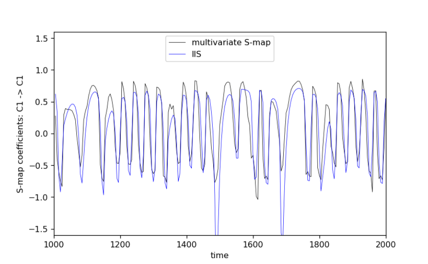

```python
plt.plot(Smap_5sp_coeffcients["Time"][1:201], tau*dC1dC1(rk4_result_df[1:201]), color = "blue", label = "IIS", linestyle = "solid", linewidth = 0.5)
plt.xlabel('time')
#plt.title('')
plt.legend(loc = "upper center", bbox_to_anchor = (0.5, 1.0))
plt.show()
```

### [8] Deriving mathematically correct interaction coefficients

#### [8.2] Solving the model

##### [8.2.1] Preparing the fine solution of the ODEs without perturbation

Since rk4() includes the evaluation of derivatives at t + deltat/2, we need to have numerical solutions with the high resolution with deltat/2

```python
t = 0.0  # initial condition (initial time, 0)
end_time = 2000
tau = 5
transient_period = 1000
write_index = 1
deltat_fine = deltat * 0.5

no_step_fine = int((end_time - transient_period) / deltat_fine) + 1
rk4_result_fine = np.zeros([no_step_fine, dim_model1 + 1]) #array for saving the time series generated

#Initial condition set
nv_rk4_fine = np.zeros([dim_model1])

#Initial condition set
nv_rk4_fine[j_R] = 1.0
nv_rk4_fine[j_C1] = 0.5
nv_rk4_fine[j_C2] = 0.8
nv_rk4_fine[j_P1] = 0.7
nv_rk4_fine[j_P2] = 0.8

#For the transient dynamics (RUN BURN)
for i in range(1, int(transient_period / deltat_fine) + 1):
  rk4(in_vec = nv_rk4_fine, out_vec = nv_rk4_fine, time = t, h_interval = deltat_fine, dim = dim_model1, diff_vec = diff_5sp)
  t = t + deltat_fine # update time

#record the initial condition after BURNING phase
rk4_result_fine[0, 0] = t
rk4_result_fine[0, 1:] = nv_rk4_fine

#After transient period, recording every time step
j = 0
for i in range(1, int((end_time - transient_period) / deltat_fine) + 1):
  rk4(in_vec = nv_rk4_fine, out_vec = nv_rk4_fine, time = t, h_interval = deltat_fine, dim = dim_model1, diff_vec = diff_5sp)
  t = t + deltat_fine # update time
  j += 1
  rk4_result_fine[j, 0] = t
  rk4_result_fine[j, 1:] = nv_rk4_fine

print(rk4_result_fine)
```

```
[[1.00000000e+03 2.85950153e-02 6.63480154e-04 5.83208148e-01
  8.39888622e-05 1.02549882e+00]
 [1.00000500e+03 2.86053566e-02 6.63248090e-04 5.83592245e-01
  8.40232330e-05 1.02539824e+00]
 [1.00001000e+03 2.86157092e-02 6.63016107e-04 5.83976577e-01
  8.40576156e-05 1.02529747e+00]
 ...
 [1.99999000e+03 1.35576997e-01 1.57286719e-02 2.92510500e-01
  4.22764558e-03 1.09439814e+00]
 [1.99999500e+03 1.35589285e-01 1.57233017e-02 2.92641545e-01
  4.22931849e-03 1.09444405e+00]
 [2.00000000e+03 1.35601597e-01 1.57179333e-02 2.92772658e-01
  4.23099215e-03 1.09448958e+00]]
```

```python
rk4_result_fine_df = pd.DataFrame(rk4_result_fine, columns = ["time", "P1", "P2", "C1", "C2", "R"])
print(rk4_result_fine_df)
```

```
            time        P1        P2        C1        C2         R
0       1000.000  0.028595  0.000663  0.583208  0.000084  1.025499
1       1000.005  0.028605  0.000663  0.583592  0.000084  1.025398
2       1000.010  0.028616  0.000663  0.583977  0.000084  1.025297
3       1000.015  0.028626  0.000663  0.584361  0.000084  1.025197
4       1000.020  0.028636  0.000663  0.584746  0.000084  1.025095
...          ...       ...       ...       ...       ...       ...
199996  1999.980  0.135552  0.015739  0.292249  0.004224  1.094305
199997  1999.985  0.135565  0.015734  0.292380  0.004226  1.094352
199998  1999.990  0.135577  0.015729  0.292510  0.004228  1.094398
199999  1999.995  0.135589  0.015723  0.292642  0.004229  1.094444
200000  2000.000  0.135602  0.015718  0.292773  0.004231  1.094490

[200001 rows x 6 columns]
```

Comparing the solutions

```python
plt.clf() #clear the figure setting
plt.xlim([1000, 2000])
plt.ylim([-0.1, 1.6])
plt.plot(rk4_result_df["time"], rk4_result_df["C1"], color = "red", label = "default delta-t", linestyle = "solid", linewidth = 0.5)
```

```
(-0.1, 1.6)
```

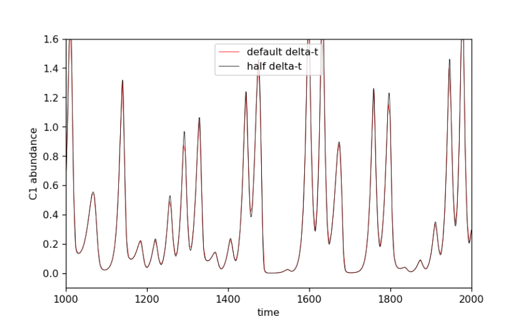

```python
plt.plot(rk4_result_fine_df["time"], rk4_result_fine_df["C1"], color = "black", label = "half delta-t", linestyle = "solid", linewidth = 0.5)
plt.xlabel('time')
plt.ylabel('C1 abundance')
#plt.title('')
plt.legend(loc = "upper center", bbox_to_anchor = (0.5, 1.0))
```

##### [8.2.3] Functions to calculate the interaction strength

```python
#ref_data: the dataset that includes the fine resolution solution of the target nonlinear ODE systems, of which record started at absolute time = transient_period
#deltax: the size of perturbation at t = h_interval/2
#start_t: usually specified as transient_period
#tau: the interval for the calculation
#dim: dimension of ODE system
#diff_vec: the vector field generated by the linearized ODEs with non-perturbed solution or the original nonlinear ODE

#This is a function that directly used the nonlinear ODE with the perturbed initial conditions
def direct_coeff(ref_data, deltax, start_t, tau, h_interval, dim, diff_vec):
  #matrix to stock results
  nv_nonlinear_p = np.zeros([dim, dim])

  tzero = start_t - transient_period + h_interval / 2  # initial condition (initial time, t_abs = start_t)
  t_index_start = int((tzero / h_interval) * 2) - 1
  t_index_end = t_index_start + int((tau / h_interval) * 2)

  #Initial condition
  nv_nonlinear_p[:, j_P1] = ref_data.iloc[t_index_start, 1:] + [deltax, 0, 0, 0, 0]
  nv_nonlinear_p[:, j_P2] = ref_data.iloc[t_index_start, 1:] + [0, deltax, 0, 0, 0]
  nv_nonlinear_p[:, j_C1] = ref_data.iloc[t_index_start, 1:] + [0, 0, deltax, 0, 0]
  nv_nonlinear_p[:, j_C2] = ref_data.iloc[t_index_start, 1:] + [0, 0, 0, deltax, 0]
  nv_nonlinear_p[:, j_R] = ref_data.iloc[t_index_start, 1:] + [0, 0, 0, 0, deltax]

  end_time = tau

  for j in range(0, dim):
    t = tzero
    for i in range(1, int(end_time / deltat) + 1):
      rk4(nv_nonlinear_p[:, j], nv_nonlinear_p[:, j], t, h_interval, dim, diff_vec)
      t = t + h_interval # update time (starting from the middle)

  #Calculate the difference between the perturbed flow and unperturbed flow
  for j in range(0, dim):
    nv_nonlinear_p[:, j] = nv_nonlinear_p[:, j] - ref_data.iloc[t_index_end, 1:]

  return nv_nonlinear_p / deltax
```

##### [8.2.5] Nonlinear ODE model for calculating all points from 1000 to 2000 with interval

The blokc using mclapply() in R is simply replaced by for loop in python, since the computational time is not large even in a laptop Windows PC.

```r
direct_coeff_5sp <- list()

start_time <- vector()
transient_period <- 1000

direct_coeff_5sp <- mclapply(1:200, function(i) {
  start_time[i] <- transient_period + (i - 1)*tau
  result_nonlinear <- direct_coeff(rk4_result_fine, deltax = 0.0001, start_t = start_time[i], tau, deltat, dim = 5, diff_5sp)
  result_nonlinear
}, mc.cores = 1)

direct_coeff_5sp[[5]]
```

Python codes and results

```python
no_step = 200
direct_coeff_5sp = np.zeros([no_step, dim_model1, dim_model1])
for i in range(0, no_step):
  start_t_i = transient_period + i * tau
  direct_coeff_5sp[i, :, :] = direct_coeff(rk4_result_fine_df, deltax = 0.0001, start_t = start_t_i, tau = 5, h_interval = deltat, dim = dim_model1, diff_vec = diff_5sp)

print(direct_coeff_5sp[4, :, :])
```

```
[[ 9.66015156e-01  5.55777646e-07  2.47424676e-01 -1.85415248e-02
   8.13953059e-01]
 [ 2.98991653e-10  7.04755958e-01 -1.35766005e-09  1.77554584e-04
   5.17432539e-08]
 [-3.73425436e-01  3.67180369e-06  2.60807298e-01 -9.90388112e-02
   3.23021456e+00]
 [ 5.36791373e-06 -6.72861934e-05 -1.92812567e-05  6.27307347e-01
   5.58722817e-04]
 [ 2.98906407e-01  3.67078268e-05 -7.92438413e-01 -7.50692094e-01
   1.68947906e+01]]
```

### [10] Comparisons for 5sp model

#### [10.1] Compare standard S-map, IIS, and CIS by direct evaluation (but without MDR S-map)

CIS by Direct evaluation: direct_IS (Eqn.19)

```python
#normalization by SD
sd_adj_C1R = rk4_result_sd[j_R] / rk4_result_sd[j_C1]
delta_C1C1 = 1
direct_dC1dC1 = direct_coeff_5sp[:, j_C1, j_C1] - delta_C1C1
direct_dC1dR = sd_adj_C1R * direct_coeff_5sp[:, j_C1, j_R]
```

##### [10.1.2] Comparison for the diagonal element (Fig. 3a: C1 -> C1): corresponding to ggplot in R

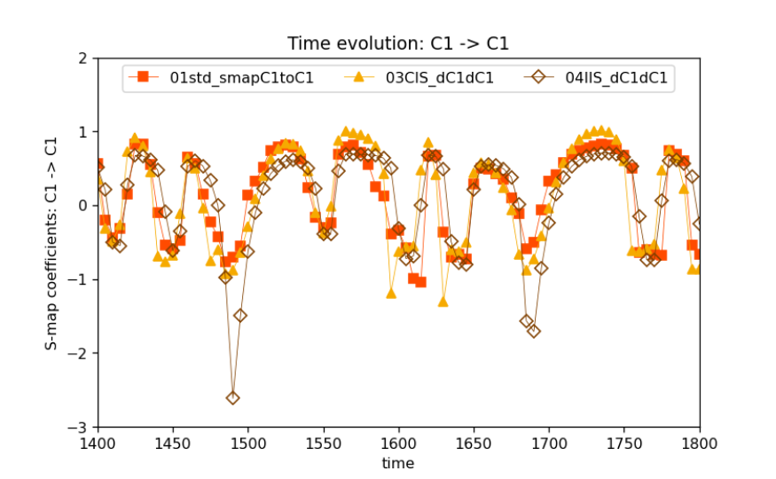

```python
plt.clf() #clear the figure setting
plt.xlim([1400, 1800])
plt.ylim([-3, 2.0])
plt.plot(Smap_5sp_coeffcients["Time"][80:161], Smap_5sp_coeffcients["∂C1/∂C1"][81:162] - delta_C1C1, color = "#ff4b00", label = "01std_smapC1toC1", linestyle = "solid", linewidth = 0.5, marker = "s")
plt.xlabel('time')
plt.ylabel('S-map coefficients: C1 -> C1')
plt.title('Time evolution: C1 -> C1')
```

```python
plt.clf() #clear the figure setting
plt.xlim([1400, 1800])
plt.ylim([0, 9])
```

```
(0.0, 9.0)
```

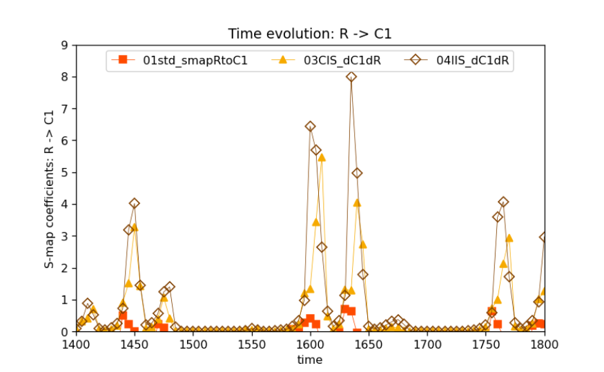

```python
plt.plot(Smap_5sp_coeffcients["Time"][80:161], tau*dC1dR(rk4_result_df[80:161]), color = "#804000", label = "04IIS_dC1dR", linestyle = "solid", linewidth = 0.5, marker = "D", fillstyle = 'none')
plt.xlabel('time')
plt.ylabel('S-map coefficients: R -> C1')
plt.legend(loc = "upper center", bbox_to_anchor = (0.5, 1.0), ncol = 3)
```